# R Notebook

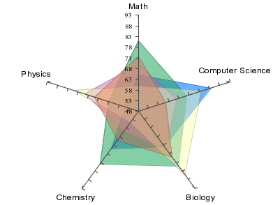

# Introduction

Let’s start with a future view of an individual’s education. Many of us have used the internet to educate ourselves with the abundance of high quality videos, papers, articles, podcasts and how-tos all over the web. Let us imagine that all of what you have learned online (throughout the entirety of your life), from the hundreds of Youtube videos, Wikipedia articles, Nature papers, and podcasts you’ve read, watched, or listened to, were all consolidated into what we might call a **digital education footprint**.

In this essay, I will propose a new way to approach education which will require significant effort to bring to life but I believe the costs will surely outweight the costs. I’ll talk about how we can use machine learning and deep learning in particular to help create our **digital education footprint**, **student journeys**, and a collective human knowledge graph. This will allow us to take the space of unstructured educational content and begin to map it unto a knowledge graph and use generative models to make educational content engaging and test a student’s knowledge no matter the subject. I will name a few benefits of such a future.

- A society where individuals do not simply compete for a degree but where they can feel safe to create their own unique journey through human knowledge and still be recognised and predictable to others
- A society where an individual’s knowledge is derived not from what we know about a degree but by their actual knowledge which is alive and therefore always evolving
- A society that better understands itself, through the understanding of the many journey’s it’s members have taken and the collective knowledge that has gone mostly unaccounted for in today’s degree based education.

I will also show that this imagined future is not only **desirable** for society but also that much of it is currently feasible mainly due to the most recent advances in machine learning, and in particular deep learning, which will enable us to begin designing such a future today.

# Concerns

## Passive Consumption

This is a concern that is widely observed. Passive watching is not equivelent to learning. There are many variables that are related to this including those that are cultural and biological.

Here I’ll focus on two points. I argue that educational content online expects the content to help a student reach a particular goal. There is nothing in the content itself, or the platforms, that reach out to reinforce or to verify the knowledge one has gained.

- Engagement
- Goal-Directed

> People watch videos casually and on the fly—and they rarely turn their phones sideways to do it. - Facebook Ads

## Untested Knowledge

It has been argued that it is hard to verify what someone has learned while consuming educational content online. This is generally true outside of those content producers who combine content and testing (i.e. Khan Academy, Udacity, Coursera) but they are generally limited compared to the vast amount of videos that are available that lack this testing.

## Predictability

Concerns #1 and #2 can be solved and it could serve the individual who is seeking to master the content of a particular or several subjects. An individual could find themselves engaging with the goal of mastering the subjects, knowing that their grasp of the knowledge would be tested.

But it does not solve the societal issue. If you are like myself, you have watched more videos and read more articles online than you did when you were in school. Possibly much more. But how does one make sense of such consumption since it is largely unstructured and from various individuals and institutions. Let us take degrees and their success in making an individual’s ability predictabe. A degree not only makes an individual predictable, in fact, it makes a whole class of individuals predictable on one crucial dimension. When we know one has a BA in Mathematics we know that they should have some knowledge of mathematics. We can imagine that an individual with such a degree has working knowledge of a familiar set of subjects (even if one doesn’t know much about mathematics) and also the type of work they might be able to do. This is because of the traditions of our educational institutions and practices. The predictability is due to our past knowledge of what a particular subject is about and the occupational outcomes of such knowledge. The bad part is that degrees are beginning to tell less and less of the story. So for all of it’s ability to reduce the complexity of gained knowledge, it is too limiting to represent a user’s true level of knowledge.

# Universal Teaching Machine

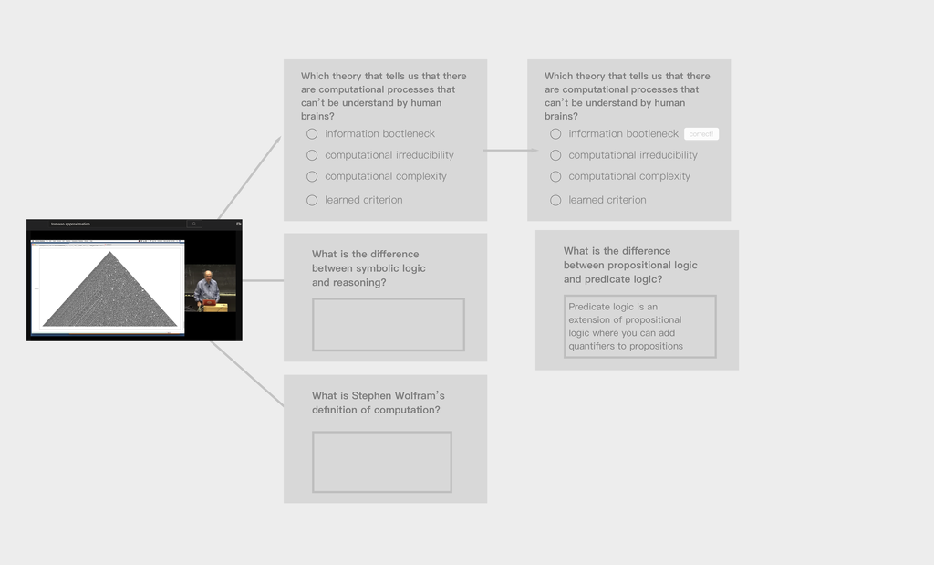

## The components

A component of a universal teaching machine should be able to take any of the billions of educational content online (and eventualyl off) and by using machine learning and deep learning techniques complete the following: - assign it to a one or more knowledge subjects (i.e. math, design, computer science) - generate a set of adequate questions and answers that test the student’s (what is x? a, b, c, or d) knowledge throughout the learning session

# Concepts

### Digital Education Footprint

The concept of a digital education footprint is is a custom symbol and profile that represents one’s education relative to that of others. Each symbol should be somewhat unique and the profile could capture the general education as well as the intricacies.

### Journeys

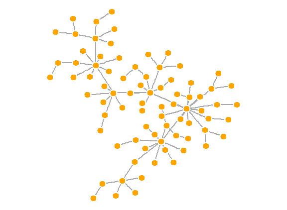

### Human Knowledge Graph

We have so far introduced **digital education footprint** and **journeys**, which claim to be the right elements to synthesis one’s education. But how does one create a path? From video to video? From topic to topic? If so, how might a machine decide on the topic? We have had plenty of advances in topic models but perhaps what we actually need is a graph of human knowledge. This graph, like Google’s knowledge graph, should be generated both from the current structure of education and also driven by unsupervised learning of new topics that don’t exist on today’s knowledge graph.

This graph would be useful so content on the web could be easily mapped to the graph adn relate one user to another as well as create trails.

## From Data to Wisdom (DIKW)

Over time, it is plausible, that our digital education footprint would be the most important representation of an individuals level of education. Even more important than our primary education; it has done much to make us predictable, but it has sacrificed the true range of an individual’s gained knowledge and wisdom coming from any other place than the institution is willing to give credit for.

Since we’ve largely rely upon large institutions to educate groups of individuals, many have grown deeply familiar with having a perfectly demarcated path towards a degree, so it has been much harder for individuals to use this abundance of knowledge to chart their own educational journey in today’s fast moving world.

## Part I - Rethinking education

E2QA - a theoretical neural network architecture to generate questions and answers from video.

## Part III - Supporting theories for deep learning

Theory of the learnable Mutual Information Joint probability

## Part IV - Survey of empirical results

RNN / CNN VQA Encoder/Decoder

## Part VI - Evaluation

OLD NLP - Grammar Deep NLP - Word2Vec